# Ejercicio 1

Lucio Cornejo

2025-04-14

## Ejemplo de lectura de datos

En la primera ejecución de este documento, no existe el archivo `Eggs.csv`, por lo cual deshabilitamos su carga.

```r
eggs <- read.csv("Eggs.csv", header=TRUE,row.names=1)             # lectura datos
head(eggs)                                                        # control
str(eggs)                                                         # estructura data-frame
print(eggs)
```

Cargamos los datos del arhivo `Eggsorg.ods`.

```r
eggs <- read_ods("Eggsorg.ods", sheet = 1)                        # lectura datos
head(eggs)                                                        # control
```

```
## # A tibble: 6 x 9
##   Name           Family   Size `Nesting ground`    Eggs  Length Width  Mass Hatch
##   <chr>          <chr>   <dbl> <chr>               <chr>  <dbl> <dbl> <dbl> <chr>
## 1 Barn owl       Owl      34   Hollow trees, barns 4-7     39.2  30.8  20.7 30
## 2 Black cap      Warbler  14   Bushes, low trees   4-6     19.6  14.7   1.9 14-15
## 3 Black redstaft Chat     14   Hales, crevices     5-6     19.4  14.4   2   13
## 4 Blackbird      Thrush   25   Trees, bushes       4-6     28.6  21     9   13-14
## 5 Blue tit       Tit      11.5 Holes               10-13   15.4  11.9   1.3 13-15
## 6 Brambling      Finch    14.5 Trees, bushes       5-6     19.5  14.6   2.2 12-13
```

```r
str(eggs)                                                         # estructura data-frame
```

```
## tibble [96 x 9] (S3: tbl_df/tbl/data.frame)
##  $ Name          : chr [1:96] "Barn owl" "Black cap" "Black redstaft" "Blackbird" ...
##  $ Family        : chr [1:96] "Owl" "Warbler" "Chat" "Thrush" ...
##  $ Size          : num [1:96] 34 14 14 25 11.5 14.5 15 95 47 15 ...
##  $ Nesting ground: chr [1:96] "Hollow trees, barns" "Bushes, low trees" "Hales, crevices" "Trees, bushes" ...
##  $ Eggs          : chr [1:96] "4-7" "4-6" "5-6" "4-6" ...
##  $ Length        : num [1:96] 39.2 19.6 19.4 28.6 15.4 19.5 20.2 85.7 43.5 19.3 ...
##  $ Width         : num [1:96] 30.8 14.7 14.4 21 11.9 14.6 15.1 58.2 30.1 14.6 ...
##  $ Mass          : num [1:96] 20.7 1.9 2 9 1.3 2.2 2.1 228 19 2.1 ...
##  $ Hatch         : chr [1:96] "30" "14-15" "13" "13-14" ...
```

Resulta necesario indicar que la columna `Name` debe considerarse una etiqueta de fila. Además, la variable `eggs` debe ser de tipo `data.frame`, no `tibble`.

```r
# Lectura con etiquetas
eggs <- read_ods("Eggsorg.ods", sheet = 1, row_names = TRUE, as_tibble = FALSE)
head(eggs)
```

```
##                          Family Size      Nesting ground  Eggs Length Width Mass Hatch
## Barn owl                    Owl 34.0 Hollow trees, barns   4-7   39.2  30.8 20.7    30
## Black cap               Warbler 14.0   Bushes, low trees   4-6   19.6  14.7  1.9 14-15
## Black redstaft             Chat 14.0     Hales, crevices   5-6   19.4  14.4  2.0    13
## Blackbird                Thrush 25.0       Trees, bushes   4-6   28.6  21.0  9.0 13-14
## Blue tit                    Tit 11.5               Holes 10-13   15.4  11.9  1.3 13-15
## Brambling                 Finch 14.5       Trees, bushes   5-6   19.5  14.6  2.2 12-13
```

```r
str(eggs)
```

```
## 'data.frame':    96 obs. of  8 variables:
##  $ Family        : chr  "Owl" "Warbler" "Chat" "Thrush" ...
##  $ Size          : num  34 14 14 25 11.5 14.5 15 95 47 15 ...
##  $ Nesting ground: chr  "Hollow trees, barns" "Bushes, low trees" "Hales, crevices" "Trees, bushes" ...
##  $ Eggs          : chr  "4-7" "4-6" "5-6" "4-6" ...
##  $ Length        : num  39.2 19.6 19.4 28.6 15.4 19.5 20.2 85.7 43.5 19.3 ...
##  $ Width         : num  30.8 14.7 14.4 21 11.9 14.6 15.1 58.2 30.1 14.6 ...
##  $ Mass          : num  20.7 1.9 2 9 1.3 2.2 2.1 228 19 2.1 ...
##  $ Hatch         : chr  "30" "14-15" "13" "13-14" ...
```

```r
# Escritura .csv
write.csv(eggs, file = "Eggs.csv")
```

Removemos los espacios extra al inicio y final de cada etiqueta de fila y columna.

```r
rownames(eggs) <- trimws(rownames(eggs), which = c("both"))
colnames(eggs)
```

```
## [1] "Family"         "Size"           "Nesting ground" "Eggs"           "Length"         "Width"          "Mass"           "Hatch"
```

```r
colnames(eggs) <- c(
  "Family", "Size", "Nesting ground", "Eggs",
  "Length", "Width", "Mass", "Hatch"
)
print(eggs)
```

```
##                         Family Size          Nesting ground  Eggs Length Width  Mass Hatch
## Barn owl                   Owl 34.0     Hollow trees, barns   4-7   39.2  30.8  20.7    30
## Black cap              Warbler 14.0       Bushes, low trees   4-6   19.6  14.7   1.9 14-15
## Black redstaft            Chat 14.0         Hales, crevices   5-6   19.4  14.4   2.0    13
## Blackbird               Thrush 25.0           Trees, bushes   4-6   28.6  21.0   9.0 13-14
## Blue tit                   Tit 11.5                   Holes 10-13   15.4  11.9   1.3 13-15
## Brambling                Finch 14.5           Trees, bushes   5-6   19.5  14.6   2.2 12-13
## Bullfinch                Finch 15.0        Bushes, conifers   4-5   20.2  15.1   2.1    13
## Canada goose             Goose 95.0         Islets, marshes   5-6   85.7  58.2 228.0 28-30
## Carrion crow              Crow 47.0              Tall trees   4-6   43.5  30.1  19.0 17-19
## Chaffinch                Finch 15.0   Bushes, trees, hedges   4-6   19.3  14.6   2.1 12-13
## Chiff-chaff            Warbler 11.0  Wood verges, hedgerows   5-6   15.5  12.0   1.3 13-14
## Chough                    Crow 39.0 Crevices, cliff, ledges   3-5   39.4  27.9  13.0 19-21
## Cirl bunting           Bunting 16.0          Bushes, hedges   3-5   20.9  15.9   2.8 11-13
## Coal tit                   Tit 11.0          Holes, burrows  7-10   14.7  11.6   1.4 14-16
## Collared dove           Pigeon 32.0           Trees, bushes     2   31.9  24.0   8.5 15-16
## Common sandpiper     Sandpiper 20.0             Lake shores     4   36.3  36.0  12.0 21-22
## Corn bunting           Bunting 18.0          Grassy hollows   5-6   23.8  17.7   3.7 12-13
## Crested tit                Tit 11.5              Tree hales   5-7   16.0  12.4   1.3 15-18
## Crossbill                Finch 16.0                Conifers   3-4   22.1  16.1   2.9 12-13
## Dotterel                Plover 22.0            Moors, scree   2-4   41.1  28.9  11.0 27-28
## Dunlin               Sandpiper 18.0          Moors, marshes   3-5   34.7  24.7  11.0    17
## Eider                     Duck 60.0        Near sea, islets   4-6   77.6  51.9 110.3 25-26
## Fieldfare               Thrush 26.0          Woodland trees   5-6   28.8  20.9   7.0 13-14
## Firecrest              Warbler  9.0                Conifers  7-12   13.5  10.3   0.7 14-15
## Gadwall                   Duck 51.0                Reedbeds  8-12   51.8  37.5  42.5    26
## Garden warbler         Warbler 14.0        Shrubs, brambles   4-5   20.1  14.8   2.5    12
## Garganey                  Duck 39.0  Dry ground, vegetation  8-11   45.3  33.3  25.7 21-23
## Goldcrest              Warbler  9.0           Tall conifers  8-11   13.6  10.3   0.7    16
## Golden Plover           Plover 28.0             Boggy moors     4   51.8  35.9  34.0    27
## Goldeneye                 Duck 46.0     Tree holes, burrows  6-11   58.4  43.2  56.5    30
## Goldfinch                Finch 12.0                   Trees   5-6   17.0  12.8   1.4 12-13
## Goosander                 Duck 62.0              Tree holes  8-12   66.4  46.4  83.5    32
## Grasshopper warbler    Warbler 13.0          Moors, marshes   5-6   18.1  13.8   1.7 13-15
## Great tit                  Tit 14.0              Tree holes  7-10   17.3 135.0   1.6 13-14
## Green sandpiper      Sandpiper 23.0  Trees on marshy ground     4   39.1  28.0  16.0 20-22
## Greenfinch               Finch 14.5          Bushes, hedges     5   20.2  14.5   2.0 13-14
## Grey wagtail           Wagtail 18.0           Holes, ledges   5-6   19.0  14.5   1.9 12-14
## Greylag goose            Goose 83.0                Reedbeds   5-8   85.3  58.0 176.0 28-29
## Howlinch                 Finch 18.0         Deciduous trees   5-6   24.5  17.5   3.4    14
```

[output cut: 42 more lines]

```
## Teal                      Duck 36.0  Dry ground, vegetotion     5   45.6  33.5  26.8 21-22
## Temminck's stint     Sandpiper 14.0                  Islets     4   28.0  20.4   6.0 13-14
## Tree sparrow           Sparrow 14.0         Holes, crevices   5-6   19.3  14.0   2.0 13-14
## Turtle dove             Pigeon 32.0           Trees, hedges   2-3   30.7  23.0   9.0 13-15
## Twite                    Finch 13.0            Ground cover   5-6   17.2  12.9   1.5 12-13
## Wheatear                  Chat 15.0          Holes, burrows   5-6   21.2  15.9   2.5    14
## Whinchat                  Chat 12.5          Grassy hollows   5-7   19.2  14.8   2.0 13-14
## Whitethroat            Warbler 14.0           Scrub, bushes   4-5   18.1  13.8   2.0 11-13
## Wigeon                    Duck 48.0    Islets, ground cover     9   53.9  38.2  44.0 22-23
## Wood sandpiper       Sandpiper 20.0             Boggy moors     4   38.3  27.0  13.0 21-24
## Wood warbler           Warbler 13.0         Woodland ground   5-6   16.1  12.6   1.3    13
## Wood-pigeon             Pigeon 41.0           Trees, bushes   2-3   40.1  28.7  18.5 15-17
## Woodlark                  Lork 15.0             Wood verges   3-4   21.6  16.3   2.7 13-15
## Yellow wagtail         Wagtail 16.5          Grassy hollows   5-6   19.1  14.3   1.9 13-14
## Yellowhammer           Bunting 16.5          Grassy hollows   3-5   21.2  15.9   2.7 12-14
```

```r
write_ods(
  eggs,
  "Eggs.ods",
  # Nueva hoja
  sheet = "Data",
  row_names = TRUE,
  col_names = TRUE
)

# Reescribimos el archivo .csv, ahora correcto
write.csv(eggs, file = "Eggs.csv")
```

## Item 6

Cargar datos.

```r
SudAmerica <- read.csv("SudAmerica.csv", row.names = 1)
SudAmerica
```

```
##           Tajo_urbano   IDH
## Argentina          86 0.833
## Bolivia            51 0.394
## Brasil             75 0.739
## Chile              86 0.863
## Colombia           70 0.758
## Ecuador            56 0.641
## Guyana             35 0.539
## Panama             54 0.731
## Paraguay           48 0.637
## Peru               70 0.600
## Suriname           48 0.749
## Uruguay            86 0.880
## Venezuela          84 0.824
```

```r
Baseball <- read.csv("Baseball.csv", row.names = 1)
Baseball
```

```
##             BattingAvg WinningPerc
## Baltimore        0.266       0.574
## Boston           0.269       0.661
## California       0.256       0.508
## Chicago          0.246       0.410
## Cleveland        0.271       0.500
## Detroit          0.259       0.467
## Kansas_City      0.250       0.508
## Milwaukee        0.271       0.525
## Minnesota        0.274       0.403
## New York         0.268       0.587
## Oakland          0.252       0.422
## Seattle          0.246       0.391
## Texas            0.263       0.548
## Toronto          0.270       0.500
```

```r
Students <- read.csv("Students.csv", row.names = 1)[, c("midterm", "final")]
Students
```

```
##    midterm final
## 1     24.5  26.0
## 2     22.5  24.5
## 3     23.5  26.5
## 4     23.5  34.5
## 5     22.5  30.5
## 6     16.0  31.0
## 7     27.5  33.5
## 8     22.5  31.0
## 9     25.0  29.5
## 10    30.0  37.5
## 11    17.5  19.5
## 12    16.5  23.5
## 13    22.5  21.0
## 14    22.5  20.0
```

[output cut: 41 more lines]

Guardar datos como archivos de tipo `.ods`.

```r
write_ods(
  SudAmerica,
  "SudAmerica.ods",
  sheet = "Data",
  row_names = TRUE,
  col_names = TRUE
)

write_ods(
  Baseball,
  "Baseball.ods",
  sheet = "Data",
  row_names = TRUE,
  col_names = TRUE
)

write_ods(
  Students,
  "Students.ods",
  sheet = "Data",
  row_names = TRUE,
  col_names = TRUE
)
```

## Item 7: Gráficos descriptor vs criterio

### SudAmerica

En los datos de `SudAmerica` se observa una no insignificante relación lineal entre el par de variables presentadas. Esto salvo, por lo menos, para las observaciones *Perú* y *Bolivia*.

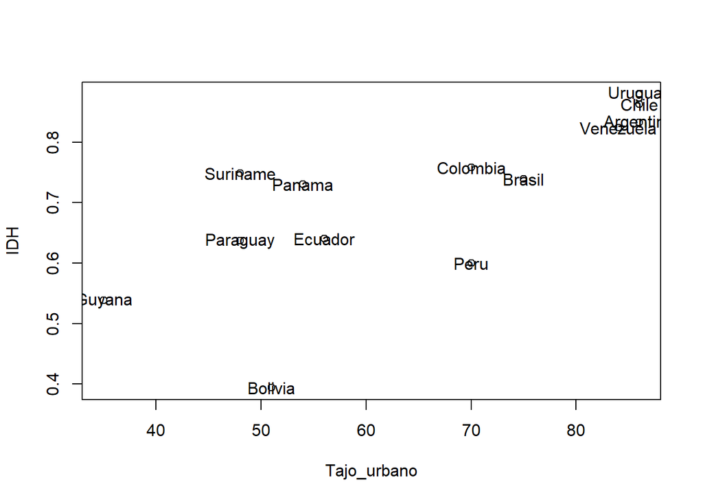

```
## integer(0)
```

```r
with(SudAmerica, {
  plot(Tajo_urbano, IDH, xlab = "Tajo_urbano", ylab = "IDH")
  text(Tajo_urbano, IDH, rownames(SudAmerica))
  identify(Tajo_urbano, IDH, rownames(SudAmerica))
})
```

### Baseball

En los datos de `Baseball` se observa una no insignificante relación lineal entre el par de variables presentadas. Sin embargo, parece haber más observaciones, en comparación a los datos de `SudAmerica`, para las cuales no se cumple esa relación lineal; por ejemplo, para `Minnesota` (en mayor grado), `Kansas_City`, y en menor grado para `Cleveland`, `Toronto` y `Milwaukee`.

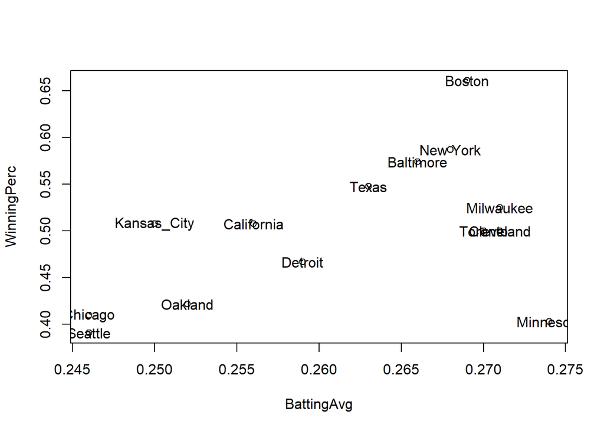

```
## integer(0)
```

```r
with(Baseball, {
  plot(BattingAvg, WinningPerc, xlab = "BattingAvg", ylab = "WinningPerc")
  text(BattingAvg, WinningPerc, rownames(Baseball))
  identify(BattingAvg, WinningPerc, rownames(Baseball))
})
```

### Students

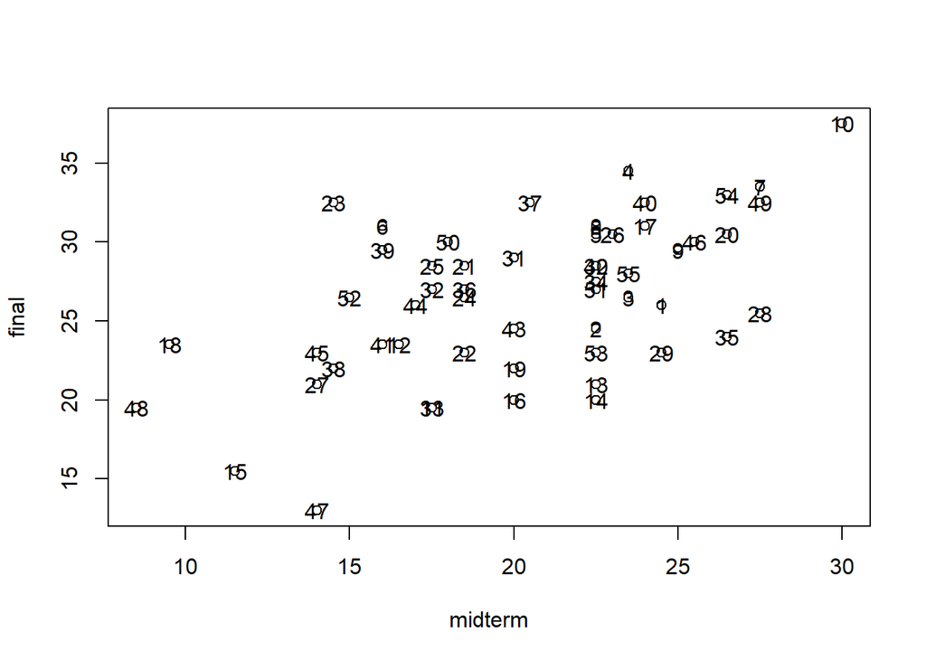

```
## integer(0)
```

```r
with(Students, {
  plot(midterm, final, xlab = "midterm", ylab = "final")
  text(midterm, final, rownames(Students))
  identify(midterm, final, rownames(Students))
})
```

## Item 8: Regresión lineal simple

### SudAmerica

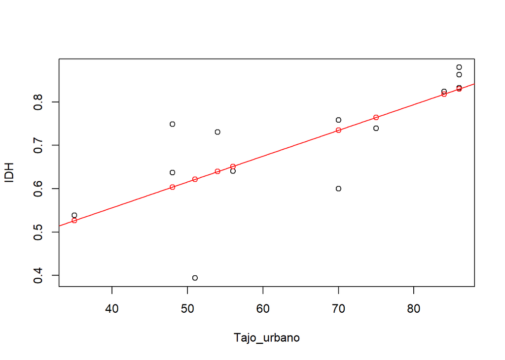

```r
lmSA <- lm(IDH ~ Tajo_urbano, data = SudAmerica)

with(SudAmerica, {
  plot(Tajo_urbano, IDH, xlab = "Tajo_urbano", ylab = "IDH")
  identify(Tajo_urbano, IDH, rownames(SudAmerica))
  # Recta de regresión
  abline(lmSA, col = "red")
  # Estimaciones
  points(Tajo_urbano, lmSA$fitted.values, col = "red")
})
```

```r
summary(lmSA)
```

```
##
## Call:
## lm(formula = IDH ~ Tajo_urbano, data = SudAmerica)
##
## Residuals:
##      Min       1Q   Median       3Q      Max
## -0.22772 -0.01044  0.01240  0.03322  0.14512
##
## Coefficients:
##             Estimate Std. Error t value Pr(>|t|)
## (Intercept) 0.318545   0.108546   2.935  0.01358 *
## Tajo_urbano 0.005945   0.001609   3.694  0.00354 **
## ---
## Signif. codes:  0 '***' 0.001 '**' 0.01 '*' 0.05 '.' 0.1 ' ' 1
##
## Residual standard error: 0.098 on 11 degrees of freedom
## Multiple R-squared:  0.5537, Adjusted R-squared:  0.5131
## F-statistic: 13.65 on 1 and 11 DF,  p-value: 0.003537
```

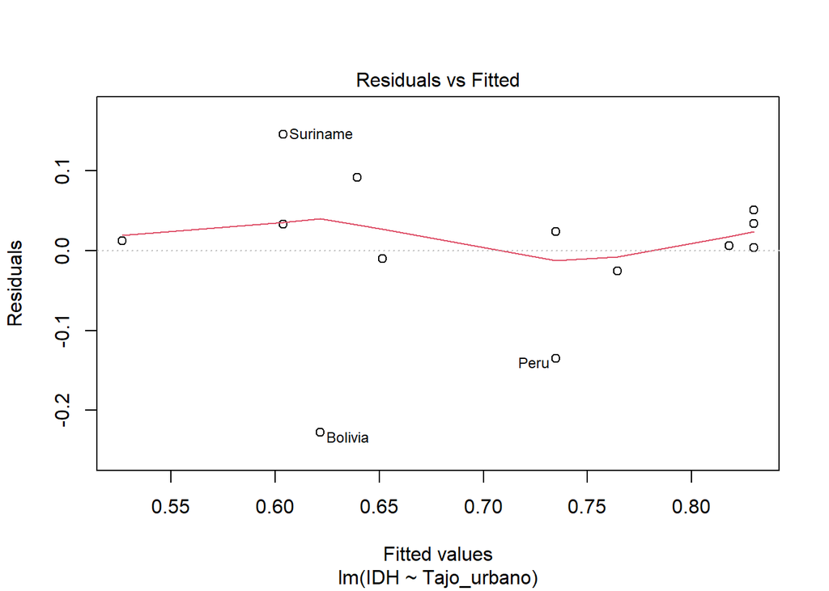

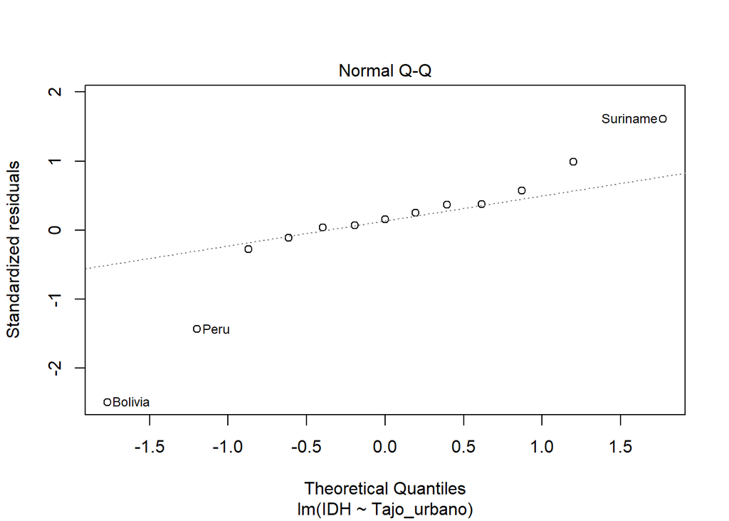

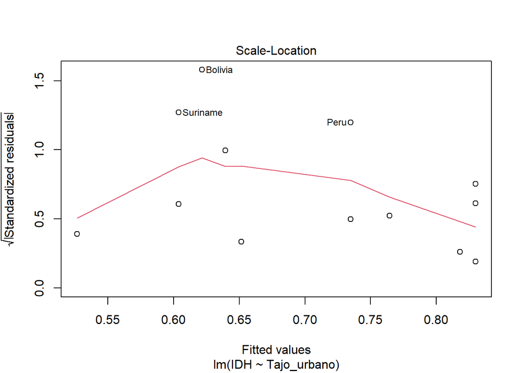

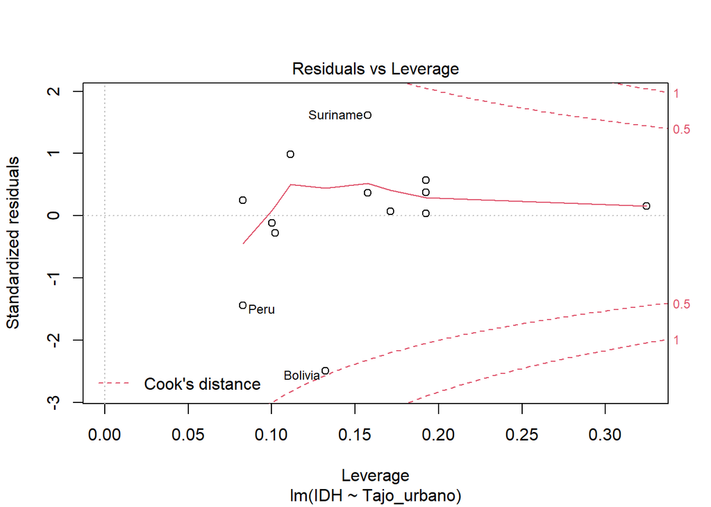

```r
plot(lmSA)
```

### Baseball

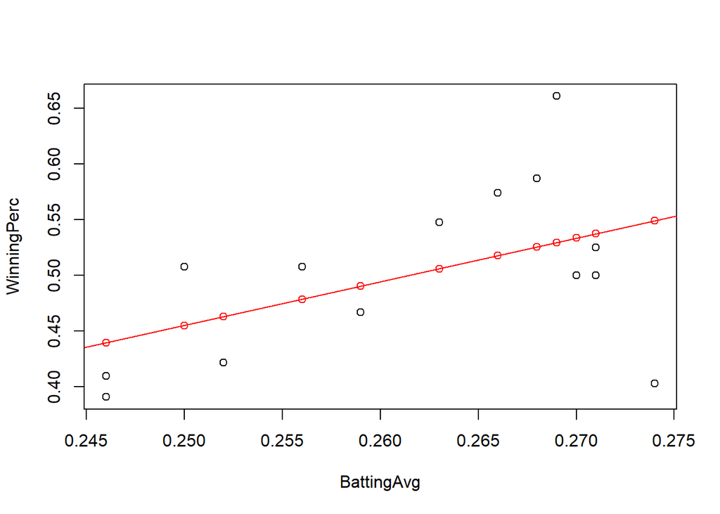

```r
lmBaseball <- lm(WinningPerc ~ BattingAvg, data = Baseball)

with(Baseball, {
  plot(BattingAvg, WinningPerc, xlab = "BattingAvg", ylab = "WinningPerc")
  identify(BattingAvg, WinningPerc, rownames(Baseball))
  # Recta de regresión
  abline(lmBaseball, col = "red")
  # Estimaciones
  points(BattingAvg, lmBaseball$fitted.values, col = "red")
})
```

```r
summary(lmBaseball)
```

```
##
## Call:
## lm(formula = WinningPerc ~ BattingAvg, data = Baseball)
##
## Residuals:
##      Min       1Q   Median       3Q      Max
## -0.14627 -0.03653 -0.01800  0.05004  0.13132
##
## Coefficients:
##             Estimate Std. Error t value Pr(>|t|)
## (Intercept)  -0.5245     0.5154  -1.018   0.3289
## BattingAvg    3.9189     1.9694   1.990   0.0699 .
## ---
## Signif. codes:  0 '***' 0.001 '**' 0.01 '*' 0.05 '.' 0.1 ' ' 1
##
## Residual standard error: 0.07017 on 12 degrees of freedom
## Multiple R-squared:  0.2481, Adjusted R-squared:  0.1854
## F-statistic: 3.959 on 1 and 12 DF,  p-value: 0.06989
```

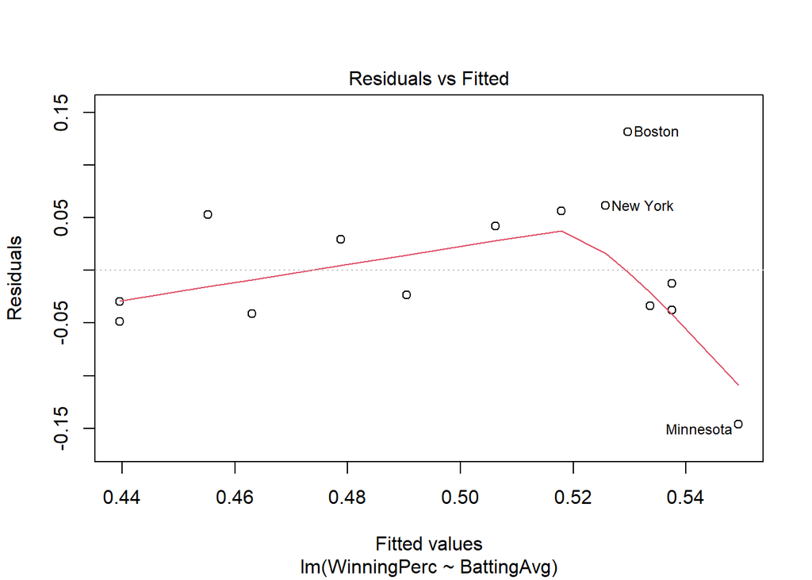

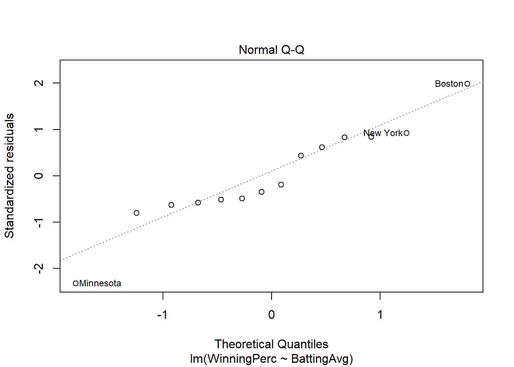

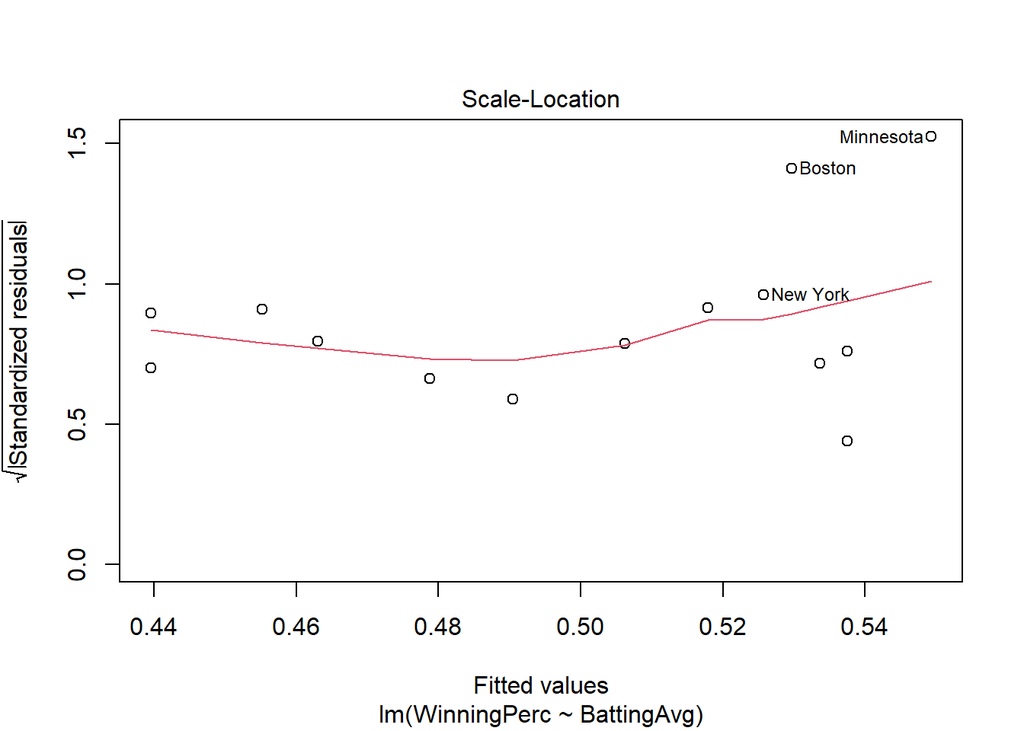

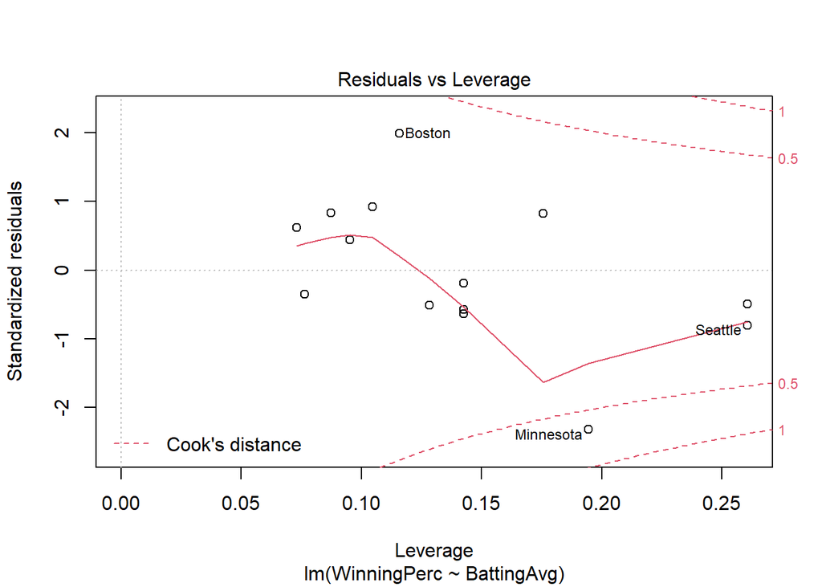

```r
plot(lmBaseball)
```

### Students

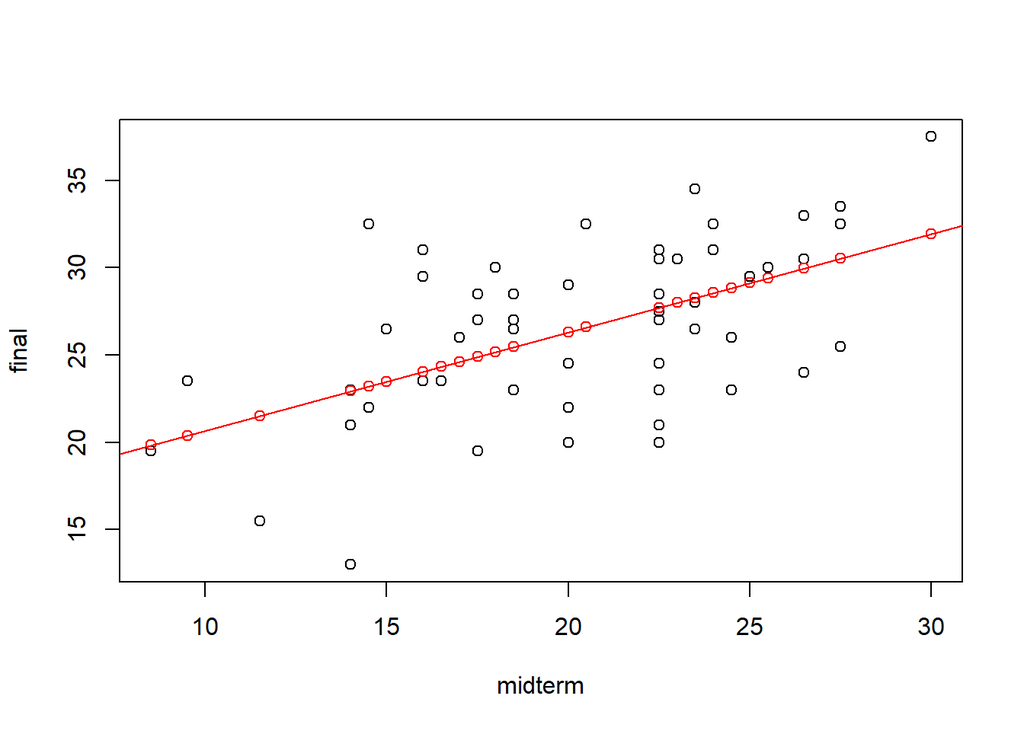

```r
lmStudents <- lm(final ~ midterm, data = Students)

with(Students, {
  plot(midterm, final, xlab = "midterm", ylab = "final")
  identify(midterm, final, rownames(Students))
  # Recta de regresión
  abline(lmStudents, col = "red")
  # Estimaciones
  points(midterm, lmStudents$fitted.values, col = "red")
})
```

```r
summary(lmStudents)
```

```
##
## Call:
## lm(formula = final ~ midterm, data = Students)
##
## Residuals:
##    Min     1Q Median     3Q    Max
## -9.932 -2.657  0.527  2.984  9.286
##
## Coefficients:
##             Estimate Std. Error t value Pr(>|t|)
## (Intercept)  15.0462     2.4822   6.062 1.44e-07 ***
## midterm       0.5633     0.1190   4.735 1.67e-05 ***
## ---
## Signif. codes:  0 '***' 0.001 '**' 0.01 '*' 0.05 '.' 0.1 ' ' 1
##
## Residual standard error: 4.192 on 53 degrees of freedom
## Multiple R-squared:  0.2973, Adjusted R-squared:  0.284
## F-statistic: 22.42 on 1 and 53 DF,  p-value: 1.675e-05
```

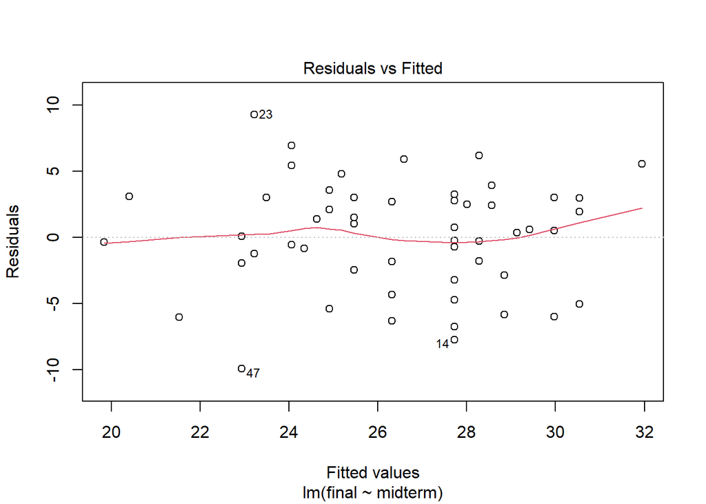

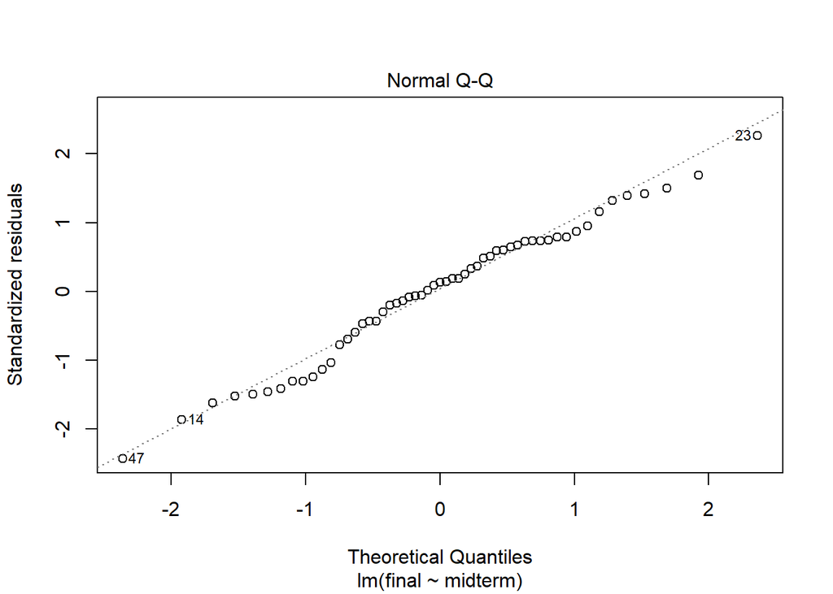

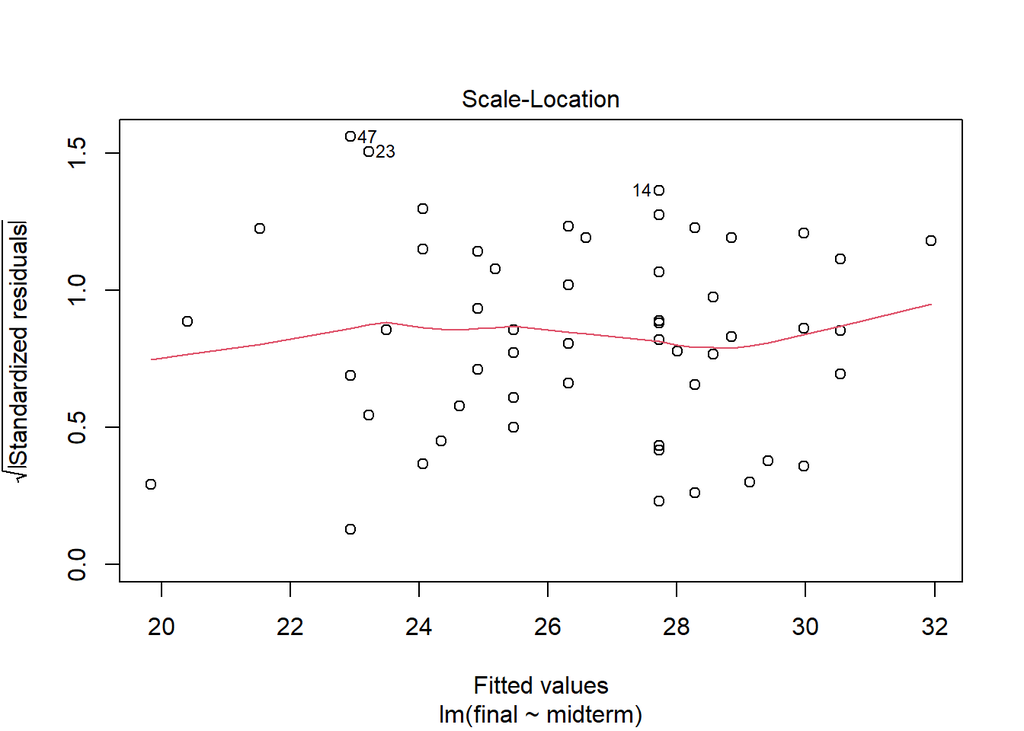

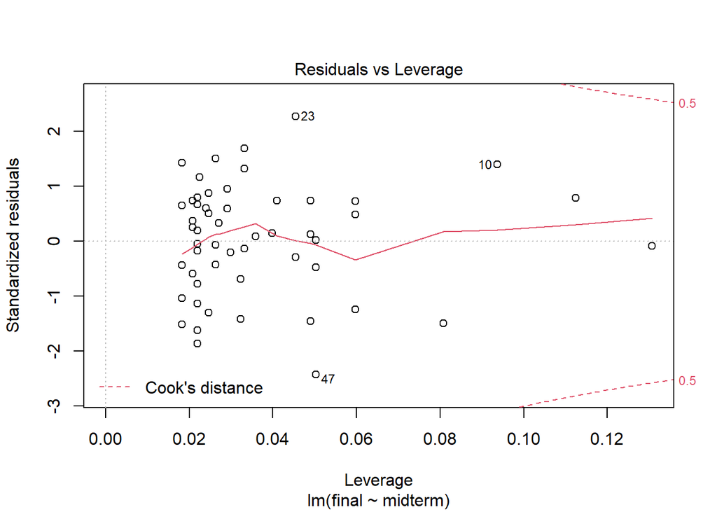

```r
plot(lmStudents)
```